# Good Plot vs. Bad Plot Lab Assignment

Avetis Mishegyan

2023-04-10

## Introduction

Today we are going to make a good plot and bad plot for lab as a competition.

**Requirements**:

- Create 2 versions of similar plots using any data set
- Plots must be made using ggplot2
  - post-processing with Adobe Illustrator or similar is not allowed
- Submit your homework by posting a markdown document containing
  - data
  - plots
  - code you used to create them
  - discussion of the plot within the markdown doc to github
- Bad plot should be as bad as possible based on the readings from Claus Wilke’s (Ch.1-5) and Healy’s (Ch.1) textbook describe the many ways that a plot can become:
  - misleading
  - difficult to interpret
  - just plain ugly
  - you should use all of the tools that you can
  - explain in text all of the ways in which the bad plot is bad (bullet points are fine, but clearly articulate each principle of data visualization that you have broken)
- Good plot should be based on the same or similar data to the first plot, but it should be good:
  - write briefly about why this is a successful plot

## Load Libraries

Here is where we will load any libraries that we will be using. These libraries contain use full packages that are collections of R functions, data, and compiled code in a well-defined format.

```r
library(tidyverse)
library(here)
library(tidytuesdayR)
library(ggplot2)
library(packcircles) # for packed circle plots
library(ggpubr) # package for making beautiful ggplot's
library(jpeg) # for reading in jpeg images
library(forcats) # for reordering within columns
```

## Load Data

Here is where we will load (ie. pull) our data from GitHub into our R script. Additionally, this is where we would also inspect our data.

```r
tuesdata <- tidytuesdayR::tt_load('2019-01-29') # reads in data using the tidytuesdayR package
clean_cheese <- tuesdata$clean_cheese
glimpse(clean_cheese) # glimpse allows us to inspect the data
```

```
## Rows: 48
## Columns: 17
## $ Year                              <dbl> 1970, 1971, 1972, 1973, 1974, 1975, …
## $ Cheddar                           <dbl> 5.79, 5.91, 6.01, 6.07, 6.31, 6.04, …
## $ `American Other`                  <dbl> 1.20, 1.42, 1.67, 1.76, 2.16, 2.11, …
## $ Mozzarella                        <dbl> 1.19, 1.38, 1.57, 1.76, 1.86, 2.11, …
## $ `Italian other`                   <dbl> 0.87, 0.92, 1.02, 1.03, 1.09, 1.12, …
## $ Swiss                             <dbl> 0.88, 0.94, 1.06, 1.06, 1.18, 1.09, …
## $ Brick                             <dbl> 0.10, 0.11, 0.10, 0.11, 0.11, 0.09, …
## $ Muenster                          <dbl> 0.17, 0.19, 0.22, 0.21, 0.23, 0.24, …
## $ `Cream and Neufchatel`            <dbl> 0.61, 0.62, 0.63, 0.66, 0.70, 0.74, …
## $ Blue                              <dbl> 0.15, 0.15, 0.17, 0.18, 0.16, 0.16, …
## $ `Other Dairy Cheese`              <dbl> 0.41, 0.41, 0.56, 0.65, 0.61, 0.57, …
## $ `Processed Cheese`                <dbl> 3.32, 3.55, 3.51, 3.31, 3.42, 3.35, …
## $ `Foods and spreads`               <dbl> 2.20, 2.31, 2.62, 2.68, 2.92, 3.35, …
## $ `Total American Chese`            <dbl> 7.00, 7.32, 7.68, 7.83, 8.47, 8.15, …
## $ `Total Italian Cheese`            <dbl> 2.05, 2.29, 2.59, 2.80, 2.95, 3.23, …
## $ `Total Natural Cheese`            <dbl> 11.37, 12.03, 13.01, 13.49, 14.41, 1…
## $ `Total Processed Cheese Products` <dbl> 5.53, 5.86, 6.13, 5.99, 6.34, 6.69, …
```

## Data Analysis

### Data Manipulation for Bad Plot

```r
bad_cheese <- clean_cheese %>%
  select(ChEdDaR = Cheddar, # selects and or renames columns
         `AmErIcAn OtHeR` = `American Other`,
         MoZzArElLa = Mozzarella,
         `ItAlIaN OtHeR` = `Italian other`,
         SwIsS = Swiss,
         BrIcK = Brick,
         MuEnStEr = Muenster,
         `CrEaM aNd NeUfChAtEl` = `Cream and Neufchatel`,
         BlEe = Blue,
         `OtHeR DaIrY ChEeSe` = `Other Dairy Cheese`,
         `PrOcEsSeD ChEeSe` = `Processed Cheese`,
         `FoOdS aNd SpReAdS` = `Foods and spreads`) %>%
  summarise(ChEdDaR = mean(ChEdDaR, na.rm = TRUE), # calculates the mean and excludes any NA's
            `AmErIcAn OtHeR` = mean(`AmErIcAn OtHeR`, na.rm = TRUE),
            MoZzArElLa = mean(MoZzArElLa, na.rm = TRUE),
            `ItAlIaN OtHeR` = mean(`ItAlIaN OtHeR`, na.rm = TRUE),
            SwIsS = mean(SwIsS, na.rm = TRUE),
            BrIcK = mean(BrIcK, na.rm = TRUE),
            MuEnStEr = mean(MuEnStEr, na.rm = TRUE),
            `CrEaM aNd NeUfChAtEl` = mean(`CrEaM aNd NeUfChAtEl`, na.rm = TRUE),
            BlEe = mean(BlEe, na.rm = TRUE),
            `OtHeR DaIrY ChEeSe` = mean(`OtHeR DaIrY ChEeSe`, na.rm = TRUE),
            `PrOcEsSeD ChEeSe` = mean(`PrOcEsSeD ChEeSe`, na.rm = TRUE),
            `FoOdS aNd SpReAdS` = mean(`FoOdS aNd SpReAdS`, na.rm = TRUE),) %>%
  pivot_longer(cols = ChEdDaR:`FoOdS aNd SpReAdS`, # pivots data into new columns as long format data
               names_to = "type",
               values_to = "mean")
glimpse(bad_cheese)
```

```
## Rows: 12
## Columns: 2
## $ type <chr> "ChEdDaR", "AmErIcAn OtHeR", "MoZzArElLa", "ItAlIaN OtHeR", "SwIs…
## $ mean <dbl> 8.88916667, 2.61833333, 6.86062500, 2.15291667, 1.15541667, 0.053…
```

### Data Manipulation for Good Plot

```r
good_cheese <- clean_cheese %>%
  select(Cheddar,
         `American Other`,
         Mozzarella,
         `Italian Other` = `Italian other`,
         Swiss,
         Brick,
         Muenster,
         `Cream and Neufchatel`,
         Blue,
         `Other Dairy Cheese`,
         `Processed Cheese`,
         `Foods and Spreads` = `Foods and spreads`) %>%
  pivot_longer(cols = Cheddar:`Foods and Spreads`,
               names_to = "type",
               values_to = "values") %>%
  mutate(type = fct_relevel(type, c("Cheddar", # reorders type column the way listed below
                                    "American Other",
                                    "Mozzarella",
                                    "Italian Other",
                                    "Swiss",
                                    "Brick",
                                    "Muenster",
                                    "Cream and Neufchatel",
                                    "Blue",
                                    "Other Dairy Cheese",
                                    "Processed Cheese",
                                    "Foods and Spreads"))) # don't need '' once columns are pivoted into a single column, can check names by typing unique(good_cheese$type)
glimpse(good_cheese)
```

```
## Rows: 576
## Columns: 2
## $ type   <fct> Cheddar, American Other, Mozzarella, Italian Other, Swiss, Bric…
## $ values <dbl> 5.79, 1.20, 1.19, 0.87, 0.88, 0.10, 0.17, 0.61, 0.15, 0.41, 3.3…
```

## Plotting Data

### Bad Plot

[figure not shown]

FiGuRe 1. BaD pLoT oF cLeAn ChEeSe DaTa.

```r
imgfile <- readJPEG(here("week_10", "data", "cheese.jpeg")) # reads in photo

data <- bad_cheese # creates data frame

packing <- circleProgressiveLayout(data$mean,
                                   sizetype = 'area') # generates the layout, and gives its center (x and y) and radius (proportional of the value)

data <- cbind(data, packing) # adds packing info (line 174) to data frame (line 173)

dat.gg <- circleLayoutVertices(packing, npoints = 50) # finds/sets center and radius to coordinates of a circle

bad_plot <- ggplot() + # makes the plot
  background_image(imgfile) + # adds image to background of ggplot
  geom_polygon(data = dat.gg, aes(x = x, # makes the bubbles
                                  y = y,
                                  group = id,
                                  fill = as.factor(id),
                                  color = "black",
                                  alpha = .6)) +
  geom_text(data = data, aes(x = x, # adds text in center, and adjusts its size
                             y = y,
                             size = radius, # should size by mean, but looks worse with radius
                             label = type)) +
  labs(title = "AmErIcAn ChEeSe CoNsUmPtIoN (LbS/PeRsOn) 1970-2017") +
  scale_fill_grey() + # sets scale fill color to grey
  theme_void() + # sets theme to void
  theme(plot.title = element_text(hjust = .5)) + # centers plot title
  coord_fixed() # fixes aspect ratio to make ovals into circles
bad_plot # prints the plot
```

This is a bad plot due to:

- Bad Taste:
  - tasteless circular packing graph
  - unnecessary legends
  - ugly mocking Spongebob Squarepants text
  - chart junk = unnecessary plot background
- Bad Data:
  - uninformative/ misleading title
  - uninformative figure caption
  - no way to measure samples (no axis scales)
- Bad Perception:
  - differences in sizes of circles are hard to read/ compare
  - circles not aligned
  - poor fill color choice (gray’s = no pop/ contrast)
  - poor choice of background = text blends in

### Good Plot

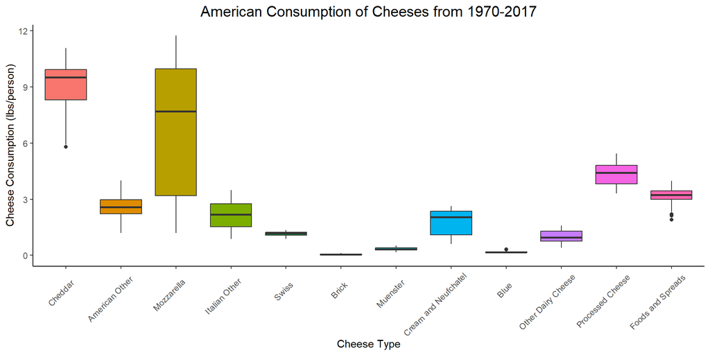

Figure 2. This figure represents the median American consumption of 12 cheese types in total from 1970 to 2017. This data comes from Tidy Tuesday of week 5 on 2019-01-29 sourced from the USDA.

```r
good_plot <- good_cheese %>%
  ggplot(aes(x = type, # plot function
             y = values,
             fill = type)) +
  geom_boxplot() + # box plot function
  labs(x = "Cheese Type",
       y = "Cheese Consumption (lbs/person)",
       title = "American Consumption of Cheeses from 1970-2017") +
  theme_classic() + # sets theme to classic
  theme(plot.title = element_text(hjust = .5, # centers plot title
                                  size = 15), # sizes plot tile
        axis.text.x = element_text(angle = 45, # angles x-axis labels
                                   vjust = .8, # moves x-axis labels horizontally
                                   hjust = .8), # moves x-axis labels vertically
        legend.position = "none") # removes legend
good_plot
```

This is a good plot due to:

- appropriate plot type for the data
- simple graph:
  - removed grid lines
  - removed unnecessary legends
  - removed unnecessary background
- easy to read text
- informative title and figure caption
- labeled axes
- can measure changes in samples
- color helps distinguish/ visually pops cheese types
- can measure differences between cheese types